# Polygenic Scores Workshop: Evaluation of Polygenic Scores in R

# Area under the Curve (AUC)

- AUC from Receiver Operating Characteristic (ROC) analysis
- AUC = Probability that a randomly selected case has a higher test score than a randomly selected control
- Range 0.5 to 1
  - 0.5 = no discrimination of cases from controls
  - 1 = perfect discrimination
- The AUC is a measure of how well the PGS predicts a binary outcome (case/control status)
- The AUC is independent to proportion of cases and controls in sample
- But, the AUC is constrained by how well your PGS reflects the underlying genotype-to-phenotype relationship
  - If your PRS does not accurately capture the genetic architecture, then AUC will be low even if there is true heritability
  - The PRS is a proxy, it doesn’t measure true genetic risk perfectly
  - So AUC is ultimatley limited by how well the PRS captures phenotype-genotype associations
- The maximum AUC achievable depend on the heritability of the disease
  - The theoretical maximum AUC a PRS can achieve is limited by the heritability of the trait.
  - For traits with low SNP heritability (h<sup>2</sup>), even a perfect PRS (trained on infinite data) can’t fully separate cases and controls.
- So the AUC has a problem with genetic interpretation
  - A high or low AUC doesn’t directly tell you about genetic architecture
  - You can’t assume that a low AUC means genetics don’t matter. Maybe your PGS is underpowered or poorly constructed, or maybe the trait is polygenic with small effects spread over many SNPs, limiting predictive ability.

## Method 1: PGS Only

- ROC analysis only using the PGS as a predictor

### ROC analysis

```r
model_PGS <- glm(Epilepsy ~ scale(SCORESUM),
                 family = binomial(link = 'logit'),
                 data = Df)

roc_model_PGS <- roc(Df$Epilepsy, model_PGS$fitted.values)

save(roc_model_PGS, file = "Results/roc_model_PGS.Rdata")
```

### Results

#### Table

```r
# Doing a one-sided test of significance (> 0.5) therefore use a one-sided 95%CI (equivalent to just the lower bound of a 90% CI)
tibble(
      AUC = as.numeric(auc(roc_model_PGS)),
      AUC_SE = sqrt(var(roc_model_PGS)),
      AUC_Z = (AUC - 0.5) / AUC_SE,
      AUC_p = pnorm(AUC_Z, mean = 0, sd = 1, lower.tail = F),
      AUC_90perc_CI_lower = as.numeric(ci(roc_model_PGS, conf.level = 0.90))[1]) %>%
  kable(caption = "AUC results and one-sided test of significance if AUC is > 0.5")
```

AUC results and one-sided test of significance if AUC is > 0.5

| AUC | AUC_SE | AUC_Z | AUC_p | AUC_90perc_CI_lower |
| --- | --- | --- | --- | --- |
| 0.6887206 | 0.0300726 | 6.275491 | 0 | 0.6392555 |

#### Graph

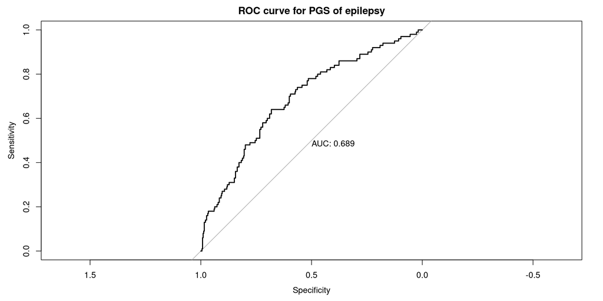

```r
plot(roc_model_PGS,
       print.auc = TRUE,
       main = paste("ROC curve for PGS of epilepsy"))
```

## Method 2: PGS + Covariates

- Find AUC attributable to PGS
- AUC(covariates plus PGS) - AUC(covariates only)

### ROC analysis

```r
# Use logistic regression models to run ROC analysis for covariates only and covariats + PGS
roc_model_covar <- roc(Df$Epilepsy, logistic_regression_covar$fitted.values)
roc_model_full <- roc(Df$Epilepsy, logistic_regression_PGS$fitted.values)

save(roc_model_covar, roc_model_full, file = "Results/roc_models_covar_full.Rdata")
```

### Results

#### Table

```r
# DeLong's test for two correlated ROC curves
sig_test <- roc.test(roc_model_full, roc_model_covar)

tibble(
    AUC_covariates_only = as.numeric(auc(roc_model_covar)),
    AUC_covariates_plus_PGS = as.numeric(auc(roc_model_full)),
    AUC_change = AUC_covariates_only - AUC_covariates_plus_PGS,
    AUC_change_Z = sig_test[["statistic"]][["Z"]],
    AUC_change_p = sig_test[["p.value"]],
    AUC_change_CI_lower = sig_test$conf.int[1],
    AUC_change_CI_upper = sig_test$conf.int[2]) %>%
    kable(caption = "AUC results and DeLong's test for two correlated ROC curves (does adding PGS to analysis significanlty increase AUC?)")
```

AUC results and DeLong’s test for two correlated ROC curves (does adding PGS to analysis significanlty increase AUC?)

[output not shown]

#### Graph

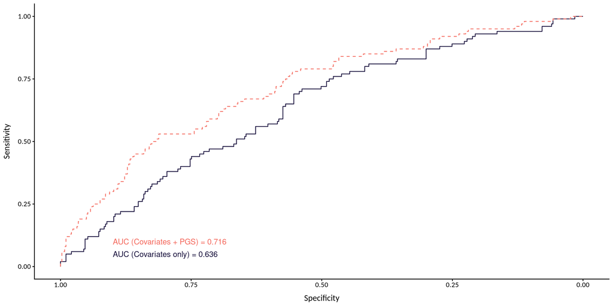

```r
roc_covar_df <- ggroc(roc_model_covar) %>%
    .[["data"]] %>%
    mutate(model = "covar")

roc_full_df  <- ggroc(roc_model_full) %>%
    .[["data"]] %>%
    mutate(model = "full")

roc_combined_df <- roc_covar_df %>%
    bind_rows(roc_full_df)

auc_covar <- round(auc(roc_model_covar), 3)
auc_full  <- round(auc(roc_model_full), 3)

ggplot(roc_combined_df, aes(x = specificity, y = sensitivity, colour = model, linetype = model)) +
    geom_line() +
    scale_x_reverse("Specificity") +
    scale_y_continuous("Sensitivity") +
    scale_linetype_manual(values = c("covar" = "solid", "full" = "dashed")) +
    scale_colour_manual(values = c("covar" = "#160F3BFF", "full" = "#F4685CFF")) +
    annotate("text",
             x = max(roc_combined_df$specificity, na.rm = TRUE) - 0.1,
             y = min(roc_combined_df$sensitivity, na.rm = TRUE) + 0.05, hjust = 0,
             label = paste("AUC (Covariates only) =", auc_covar), color = "#160F3BFF") +
    annotate("text",
             x = max(roc_combined_df$specificity, na.rm = TRUE) - 0.1,
             y = min(roc_combined_df$sensitivity, na.rm = TRUE) + 0.05 + 0.05,
             hjust = 0, label = paste("AUC (Covariates + PGS) =", auc_full), color = "#F4685CFF") +
    theme_classic() +
    theme(text = element_text(family = "Calibri"),
          axis.text = element_text(size = 10),
          axis.title.x = element_text(size = 12, colour = "black", margin = margin(10,0,0,0)),
          axis.title.y = element_text(size = 12, colour = "black", margin = margin(0,10,0,0)),
          legend.title = element_blank(),
          legend.text = element_text(size = 10, colour = "black"),
          legend.position = "none")
```